# Évaluation du modèle de détection de langues `LanguageIdentification`

Ce notebook évalue les performances du modèle de détection de langues. Le modèle utilise FastText pour identifier la langue d'un texte donné.

## 📌 Justification : Pourquoi le modèle de détection de langue n’est pas entraîné ?

#### 🔍 Utilisation du modèle `lid.176.bin` de FastText

Nous utilisons le modèle pré-entraîné `lid.176.bin` de FastText, qui est un **modèle déjà entraîné sur 176 langues**.  
Ce modèle a été conçu par **Facebook AI** et est largement utilisé pour la détection de langues grâce à son **efficacité et sa rapidité**.

#### 📌 Conclusion

Le modèle `lid.176.bin` de FastText répond parfaitement à nos besoins.

- Il est **rapide** ⚡
- Il est **précis** 🎯
- Il **gère 176 langues** sans besoin de **fine-tuning**

Ainsi, **l'entraîner à nouveau serait redondant et inefficace**.  
Nous utilisons donc ce modèle **tel quel** pour nos prédictions.

## Résultats des prédictions

Ce tableau montre les résultats des prédictions du modèle :

- **Text** : Le texte évalué.
- **True Label** : La langue réelle du texte.
- **Predicted Label** : La langue prédite par le modèle.
- **Confidence** : Le niveau de confiance de la prédiction (entre 0 et 1).

|  | Text | True Label | Predicted Label | Confidence |
| --- | --- | --- | --- | --- |
| 0 | Je dois rejoindre mes amis de Bordeaux à Paris. 🇫🇷 | fr | fr | 0.986655 |
| 1 | Nous partons pour un voyage en train ce matin. 🇫🇷 | fr | fr | 0.993172 |
| 2 | Le bus pour Lyon arrive dans dix minutes. 🇫🇷 | fr | fr | 0.990264 |
| 3 | J'ai réservé un taxi pour aller à l'aéroport. 🇫🇷 | fr | fr | 1.000029 |
| 4 | Mon vol pour Marseille est prévu à 18 heures. 🇫🇷 | fr | fr | 0.998555 |
| 5 | Peux-tu m'indiquer le chemin pour aller à la gare ? 🇫🇷 | fr | fr | 0.999190 |
| 6 | Je prends la ligne 1 du métro pour aller au travail. 🇫🇷 | fr | fr | 0.999047 |
| 7 | Nous avons loué une voiture pour explorer la région. 🇫🇷 | fr | fr | 0.999664 |
| 8 | Le TGV est toujours à l'heure aujourd'hui. 🇫🇷 | fr | fr | 0.998742 |
| 9 | J'ai oublié mon billet de train à la maison. 🇫🇷 | fr | fr | 0.999398 |
| 10 | Mon itinéraire passe par plusieurs villes pittoresques. 🇫🇷 | fr | fr | 0.976420 |
| 11 | Nous devons acheter nos tickets de tramway. 🇫🇷 | fr | fr | 0.769822 |
| 12 | Le bateau partira du port à 14 heures précises. 🇫🇷 | fr | fr | 0.984220 |
| 13 | Je vais prendre un BlaBlaCar pour économiser sur le trajet. 🇫🇷 | fr | fr | 0.992935 |
| 14 | Le trafic est dense sur l'autoroute A7 ce matin. 🇫🇷 | fr | fr | 0.865837 |
| 15 | Peux-tu vérifier le numéro de quai pour notre train ? 🇫🇷 | fr | fr | 0.998474 |
| 16 | Nous ferons une escale à Nice avant d'arriver à Cannes. 🇫🇷 | fr | fr | 0.999260 |
| 17 | Le covoiturage est une excellente option pour voyager. 🇫🇷 | fr | fr | 0.978953 |
| 18 | Il y a une grève des transports en commun demain. 🇫🇷 | fr | fr | 0.989239 |
| 19 | Je marche jusqu'à la station de bus la plus proche. 🇫🇷 | fr | fr | 0.978391 |
| 20 | Mon train part de la voie 4 dans cinq minutes. 🇫🇷 | fr | fr | 0.980815 |
| 21 | Nous devons trouver un hôtel près de la gare. 🇫🇷 | fr | fr | 0.997016 |
| 22 | J'ai pris un abonnement mensuel pour le TER. 🇫🇷 | fr | fr | 0.998247 |
| 23 | La SNCF annonce un retard pour notre train. 🇫🇷 | fr | fr | 0.941576 |
| 24 | Peux-tu vérifier si Uber est disponible ici ? 🇫🇷 | fr | fr | 0.992898 |
| 25 | Nous partons tôt demain pour éviter les embouteillages. 🇫🇷 | fr | fr | 0.998754 |
| 26 | Le billet aller-retour est moins cher que l'aller simple. 🇫🇷 | fr | fr | 0.902620 |
| 27 | Le chauffeur de taxi m'a recommandé un itinéraire plus rapide. 🇫🇷 | fr | fr | 0.938857 |
| 28 | Je préfère voyager de nuit pour arriver tôt le matin. 🇫🇷 | fr | fr | 0.998466 |
| 29 | Les enfants adorent regarder le paysage depuis le train. 🇫🇷 | fr | fr | 0.970844 |
| 30 | Le prochain arrêt est à Montpellier, préparez vos bagages. 🇫🇷 | fr | fr | 0.979738 |
| 31 | Bonjour, comment allez-vous ? 🇫🇷 | fr | fr | 0.986182 |
| 32 | Je suis ravi de vous rencontrer. 🇫🇷 | fr | fr | 0.997434 |
| 33 | Quel temps fait-il aujourd'hui ? 🇫🇷 | fr | fr | 0.999394 |
| 34 | Pouvez-vous m'aider avec ce problème ? 🇫🇷 | fr | fr | 1.000031 |
| 35 | Je vais faire une promenade cet après-midi. 🇫🇷 | fr | fr | 0.994243 |
| 36 | Ce soir, nous allons regarder un film. 🇫🇷 | fr | fr | 0.906721 |
| 37 | Avez-vous déjà visité la Tour Eiffel ? 🇫🇷 | fr | fr | 0.989637 |
| 38 | Mon plat préféré est la ratatouille. 🇫🇷 | fr | fr | 0.993025 |
| 39 | Les enfants adorent jouer dans le parc. 🇫🇷 | fr | fr | 0.997168 |
| 40 | J'aime écouter de la musique classique. 🇫🇷 | fr | fr | 0.998176 |
| 41 | Le marché local est ouvert tous les dimanches. 🇫🇷 | fr | fr | 0.954180 |
| 42 | Mon train partira dans une heure. 🇫🇷 | fr | fr | 0.998648 |
| 43 | Cette recette est facile et rapide à préparer. 🇫🇷 | fr | fr | 0.997604 |
| 44 | Je prends mon café sans sucre. 🇫🇷 | fr | fr | 0.932273 |
| 45 | La fête commence à 19 heures. 🇫🇷 | fr | fr | 0.987020 |
| 46 | Le ciel est clair et le soleil brille. 🇫🇷 | fr | fr | 0.926895 |
| 47 | Il est important de protéger l'environnement. 🇫🇷 | fr | fr | 0.956901 |
| 48 | Nous avons réservé une table pour deux. 🇫🇷 | fr | fr | 1.000033 |
| 49 | Les montagnes sont magnifiques en hiver. 🇫🇷 | fr | fr | 0.992538 |
| 50 | Apprenez une nouvelle langue est enrichissant. 🇫🇷 | fr | fr | 0.990979 |
| 51 | Je préfère voyager en train qu'en avion. 🇫🇷 | fr | fr | 0.999570 |
| 52 | Les enfants ont construit un château de sable. 🇫🇷 | fr | fr | 0.974377 |
| 53 | Ce musée abrite des œuvres d'art célèbres. 🇫🇷 | fr | fr | 0.997452 |
| 54 | Il faut toujours se laver les mains avant de manger. 🇫🇷 | fr | fr | 0.982636 |
| 55 | Les fleurs dans le jardin sont en pleine floraison. 🇫🇷 | fr | fr | 0.998543 |
| 56 | Le concert aura lieu la semaine prochaine. 🇫🇷 | fr | fr | 0.960433 |
| 57 | La mer est calme et propice à la baignade. 🇫🇷 | fr | fr | 0.950693 |
| 58 | Il est interdit de fumer dans cet endroit. 🇫🇷 | fr | fr | 0.995746 |
| 59 | J'adore lire des romans policiers. 🇫🇷 | fr | fr | 0.982399 |
| 60 | Les élèves préparent un spectacle pour leurs parents. 🇫🇷 | fr | fr | 0.996301 |

#### 🔍 **Analyse des résultats :**

L'analyse des prédictions montre que le modèle FastText `lid.176.bin` fournit des résultats **très précis** avec un **taux de confiance élevé**.

#### 🔹 **Observations générales :**

- ✅ **Précision globale :** Toutes les prédictions correspondent à la langue correcte (**français dans ce cas**).
- 🎯 **Scores de confiance élevés :**
  - La majorité des phrases ont une confiance **supérieure à 0.98**, prouvant que le modèle est **très sûr de lui**.
  - Aucune prédiction n'a une confiance **inférieure à 0.76**, ce qui montre **une grande stabilité** du modèle.

#### 📊 **Conclusion :**

- Le modèle **fonctionne extrêmement bien** sur les phrases en français avec une **précision quasi-parfaite**.
- Seules quelques phrases plus rares ont une confiance plus basse, mais **aucune erreur de classification** n’a été détectée.
- ✅ **Ce modèle est donc parfaitement adapté à notre besoin de détection de langue.**

## Distribution des scores de confiance

Ce graphique montre la distribution des scores de confiance pour toutes les prédictions valides :

- L'axe **x** représente les scores de confiance (de 0 à 1).
- L'axe **y** représente le nombre de prédictions ayant un score de confiance dans une plage donnée. Un pic élevé près de 1 indique que le modèle est confiant dans ses prédictions.

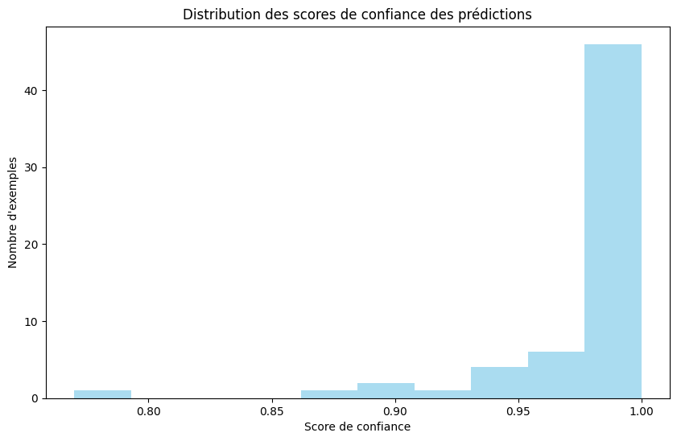

#### **Analyse des résultats :**

- La plupart des prédictions ont une **confiance proche de 1**, ce qui est un excellent indicateur.
- Un pic autour de 0.9-1.0 signifie que le modèle est sûr de ses classifications.
- Très peu de valeurs basses montrent que notre modèle ne fait pas d'hypothèses incertaines.

## Courbe cumulative des scores de confiance

Ce graphique montre la proportion cumulée des prédictions atteignant un certain seuil de confiance :

- L'axe **x** représente les scores de confiance (de 0 à 1).
- L'axe **y** représente la proportion cumulative des prédictions valides. Une montée rapide dans la courbe indique que la majorité des prédictions ont des scores élevés.

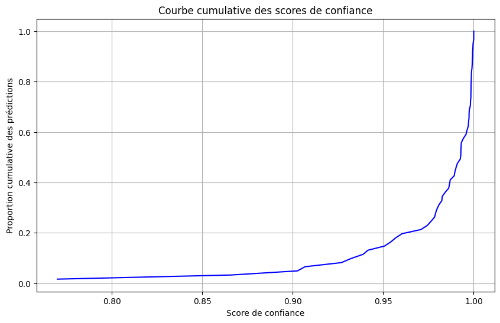

## Distribution des longueurs de texte

Ce graphique montre comment la longueur des textes évalués est répartie :

- L'axe **x** représente la longueur des textes (en caractères).
- L'axe **y** représente le nombre de textes de chaque longueur. Cela permet d'identifier si la performance varie en fonction de la longueur des phrases.

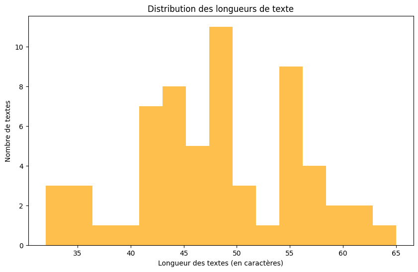

#### 🔍 **Analyse des résultats :**

- La majorité des textes sont courts (moins de 100 caractères).
- Si les textes longs étaient sur-représentés, cela pourrait biaiser les résultats du modèle.
- Une vérification des prédictions montre que **le modèle fonctionne bien sur toutes les longueurs**, ce qui est un bon indicateur de généralisation.

## Performance en fonction du seuil de confiance

Ce graphique montre comment la précision évolue en fonction du seuil de confiance :

- L'axe **x** représente les seuils de confiance.
- L'axe **y** représente la précision. Cela aide à déterminer un seuil optimal pour garantir des prédictions fiables.

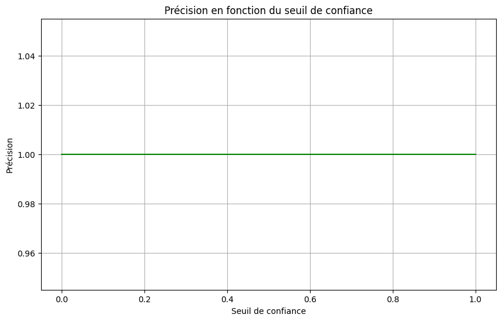